# Confidence/Hypothesis testing of Tooth Growth among Guinea Pigs

Gowri Shankar

09/17/2015

## Exploration of Tooth Growth among Guinea Pigs

Original study was conducted by EW Crampton at Macdonald College, McGill Univ(Quebec Canada). http://jn.nutrition.org/content/33/5/491.full.pdf During world war II, soldiers suffered sever Vitamin C deficiency and fell sick. This study was conducted to identify dosage levels and physical methods through which the problem to be addressed. 60 Subjects of Guinea Pigs are taken and divided into two groups. Each group was sujected to different ways through which Vitamin C is infused. Further the 2 groups were divided into 3 sub-groups for different dosage levels.

Following graph shows the variation in dosage levels(0.5, 1, 2) and length of odontoblasts.

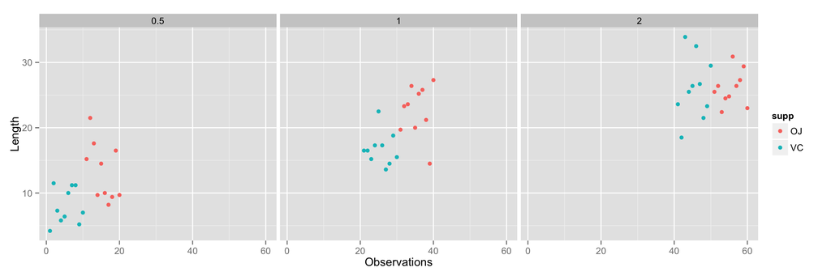

Above plot clearly indicates, as the dossage level increases, lenght of odontoblasts increase.

This is again proved with the following boxplot.

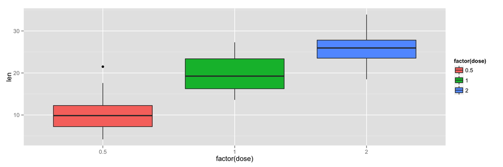

However the difference in methods(Orange Jucie(OJ), Vitamin C ) is insignificant

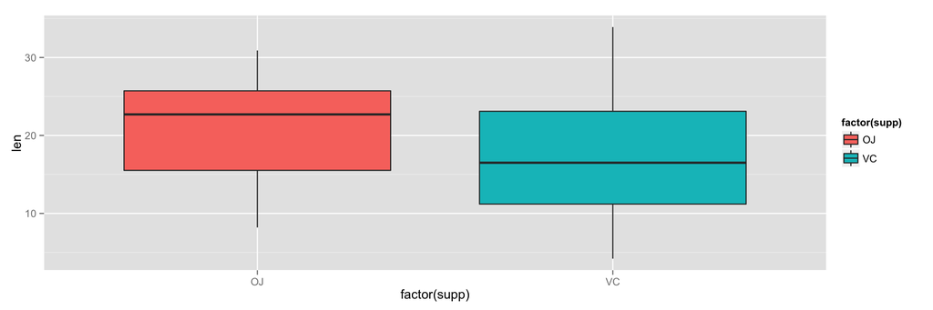

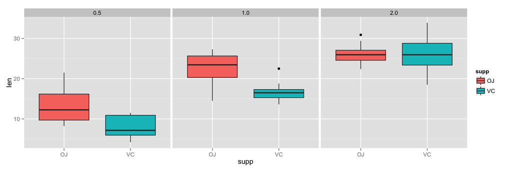

## Confidence Interval & Hypothesis Tests

** Analysing based on supp**

```r
vc <- tg[1:30,]$len
oj <- tg[31:60,]$len

test_by_supp <- sapply(data.frame(vc, oj), function(x){
    t.test(x)$conf.int
})

colnames(test_by_supp) <- c("VC", "OC")
rownames(test_by_supp) <- c("Lower", "Upper")
test_by_supp
```

```
##             VC       OC
## Lower 13.87675 18.19678
## Upper 20.04992 23.12989
```

**Analysing individually by dosage and supplement method**

We assume the data is IID normal and distributed roughly symmetric and gaussian. To get more confidence, we shal do a t-test on subsets of the data and observe the confidence interval

```r
dt_M <- data.frame(tg[1:10,]$len, tg[11:20,]$len, tg[21:30,]$len, tg[31:40,]$len, tg[41:50,]$len, tg[51:60,]$len)

test_result <- sapply(dt_M, function(x){
    t.test(x)$conf.int
})

colnames(test_result) <- c("VC_0.5", "VC_1.0", "VC_2.0", "OJ_0.5", "OJ_1.0", "OJ_2.0")
rownames(test_result) <- c("Lower", "Upper")

test_result
```

```
##         VC_0.5   VC_1.0   VC_2.0   OJ_0.5   OJ_1.0   OJ_2.0
## Lower 6.015176 14.97066 22.70791 10.03972 19.90227 24.16069
## Upper 9.944824 18.56934 29.57209 16.42028 25.49773 27.95931
```

The above results are the independent group t confidence intervals. We have compared the mean mean length of odontoblasts with in the subgroups.

**Two sample t-test**

```r
tg_supp <- data.frame(tg[1:30,]$len, tg[31:60,]$len)
res_supp <- t.test(tg_supp[,1], tg_supp[,2], paired = FALSE, var.equal = F)

tg_05 <- data.frame(tg[1:10,]$len, tg[31:40,]$len)
tg_05_dose <- t.test(tg_05[,1], tg_05[,2], paired = FALSE, var.equal = F)

tg_10 <- data.frame(tg[11:20,]$len, tg[41:50,]$len)
tg_10_dose <- t.test(tg_10[,1], tg_10[,2], paired = FALSE, var.equal = F)

tg_20 <- data.frame(tg[21:30,]$len, tg[51:60,]$len)
tg_20_dose <- t.test(tg_20[,1], tg_20[,2], paired = FALSE, var.equal = F)
```

## Conclusion

[output not shown]